# Neural Net RMD

Brayden Ross

March 28, 2019

## Image Recognition And Machine Learning

What types of things are possible for your computer to do? We know it can do math, play games, plan events, and help with schoolwork. But it can also recognize images. Machine Learning has made it possible for computers to learn from images and predict what they are. This is an exploration of one of the very first image recognition data projects, the **MNIST Digit Recognizer Project**. The aim of this project was to get a computer to correctly identify digits from a set of pixels and their brightness at a high rate of accuracy. The most accurate models found in recent years have been neural networks. While not the most efficient, neural networks provide high rates of accuracy for image recognition.

Other models explored in this project are Random Forests and Support Vector Machines. We can examine the accuracy of each and compare them to one another.

# Training Data and EDA

Before we dive into the “Black Boxes” of machine learning algorithms, let’s explore our dataset first.

What does the datset look like? Taking a look at the first 10 columns:

```r
names(train[,1:10])
```

```
##  [1] "label"  "pixel0" "pixel1" "pixel2" "pixel3" "pixel4" "pixel5"
##  [8] "pixel6" "pixel7" "pixel8"
```

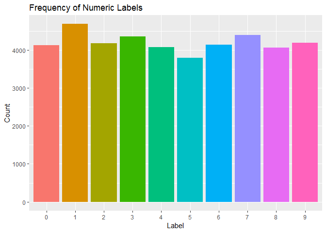

```r
colorCount <- length(unique(train$label))
ggplot(data = train, aes(x = label, fill = label)) + geom_bar() + guides(fill = FALSE) + labs(title = "Frequency of Numeric Labels", y = "Count", x = "Label")
```

Seems to be pretty evenly distributed, so we won’t have to worry about bias towards one label over others.

The pixel labels are the individual pixels in the image and their respective brightness. The brightness has a range of 0, 255, 0 being black and 255 being totally white. Eventually we’ll want to standardize that to be between 0 and 1 for our neural net, but for now we’ll leave it as is.

So what is the computer going to be seeing? Well, let’s just plot the very first digit in our training set with all its pixels to get an idea of what we can expect. The first digit in our training set labels is a 1.

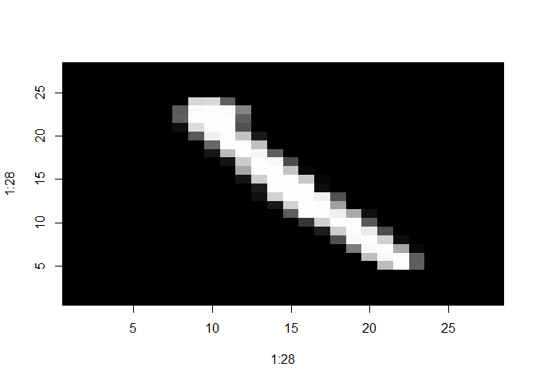

```r
im<-matrix((train[1,2:ncol(train)]), nrow=28, ncol=28)
im_numbers <- apply(im, 2, as.numeric)
image(1:28, 1:28, im_numbers, col=gray((0:255)/255))
```

Does that look like a one to you? Although its quite slanted, its still a one. The computer will have to recognize this by examining each individual pixel in the plot and its brightness.

Since this dataset has pre-extracted features, theres not much additional work we need to do to manipulate it. The dataset already has what it needs. However, since we are going to be using Support Vector Machines (SVM), we will need to remove all the columns which have 0 variance. These are pixels that have 0 brightness in any of the images. A good example would be in the image above in the top left corner. There likely won’t be many images that use that corner to show a pixel of an image, so we can remove them for the SVM.

```r
train$label <- as.numeric(train$label)
zerofeature <- sapply(X = train, FUN = max) != 0
train$label <- as.factor(train$label)
svmdat <- train[,zerofeature]
ncol(train)
```

```
## [1] 785
```

```r
ncol(svmdat)
```

```
## [1] 709
```

To remove the proper columns, we used `sapply` to keep all the columns with a max that was not equal to 0. Above, we can see first the dimensions of the training set, and the dimensions of the SVM dataset with all the zero columns removed. We removed 76 columns! We’re all set to go for our SVM model.

## Modeling

Let’s start our modeling, with the most basic out of the three first, the Random Forest. With our random forest, there’s no need to standardize our data, but for the purposes of this project, we do want to scale down the parameters so it doesn’t take 3 hours to complete training. First we’ll split our training data into training and validation sets so we can test the accuracy of the model.

```r
set.seed(1234)
inTrainfirst <- createDataPartition(y=train$label, p=0.7, list=FALSE)
trainfirst <- train[inTrainfirst,]
testfirst <- train[-inTrainfirst,]
```

```r
rf1 <- randomForest(y = trainfirst[,1],x = trainfirst[,2:ncol(trainfirst)],
                    nodesize = 3000, ntree = 20)
```

Now that we’ve trained our model, we can predict it on our validation set. We’ll use a confusion matrix to examine the results of our predictions. This will be useful due to the fact that it provides sensitivity levels, showing which digits the algorithm is having a hard time predicting correctly.

```r
predictionsRF <- predict(rf1, testfirst)
caret::confusionMatrix(predictionsRF, testfirst$label)
```

```
## Confusion Matrix and Statistics
##
##           Reference
## Prediction    1    2    3    4    5    6    7    8    9   10
##         1  1155    0   34   35   20  109  139    3   28   13
##         2     1 1356  104   50   15   64   39   45  152   21
##         3    10   35  911   58   14   46   63   53   86   29
##         4    11    4   55  973    5  428   16    6   70   12
##         5     3    0   21    7  879   57   33   42    9  272
##         6     0    0    0    0    0   60    4    0    1    0
##         7    17    0   30   15   55   71  892    3   78   15
##         8    12    5   36   56   53  114   12 1113   32  197
##         9    26    4   56   21   17   45   41   10  666   22
##         10    4    1    6   90  163  144    2   45   96  675
##
## Overall Statistics
##
##                Accuracy : 0.6891
##                  95% CI : (0.6809, 0.6972)
##     No Information Rate : 0.1115
##     P-Value [Acc > NIR] : < 2.2e-16
##
##                   Kappa : 0.6539
##  Mcnemar's Test P-Value : < 2.2e-16
##
## Statistics by Class:
##
##                      Class: 1 Class: 2 Class: 3 Class: 4 Class: 5 Class: 6
## Sensitivity           0.93220   0.9651  0.72706  0.74559  0.71990 0.052724
## Specificity           0.96645   0.9561  0.96526  0.94624  0.96097 0.999564
## Pos Pred Value        0.75195   0.7342  0.69808  0.61582  0.66440 0.923077
## Neg Pred Value        0.99241   0.9954  0.96971  0.96986  0.96966 0.913973
## Prevalence            0.09836   0.1115  0.09948  0.10360  0.09694 0.090346
## Detection Rate        0.09170   0.1077  0.07232  0.07725  0.06978 0.004763
## Detection Prevalence  0.12194   0.1466  0.10360  0.12544  0.10503 0.005160
## Balanced Accuracy     0.94933   0.9606  0.84616  0.84592  0.84043 0.526144
##                      Class: 7 Class: 8 Class: 9 Class: 10
## Sensitivity           0.71878  0.84318  0.54680   0.53742
## Specificity           0.97499  0.95415  0.97873   0.95141
## Pos Pred Value        0.75850  0.68282  0.73348   0.55057
## Neg Pred Value        0.96944  0.98112  0.95277   0.94890
## Prevalence            0.09852  0.10480  0.09670   0.09971
## Detection Rate        0.07082  0.08836  0.05287   0.05359
## Detection Prevalence  0.09336  0.12941  0.07209   0.09733
## Balanced Accuracy     0.84688  0.89867  0.76276   0.74442
```

Examining our accuracy, it seems relatively low, but for the minimal time and effort we put in, the Random Forest performs surprisingly well. The sensitivity reports are one digit greater than the actual label because of how caret works using confusion matrices, so the hardest digits for the model to predict seem to be 5, 8 and 9. This makes sense due to the fact that they are somewhat similar in shape and the algorithm doesn’t have enough time with it’s parameters to distinguish the nuances of the digits.

Moving on to our Support Vector Machine model, we’ll need to use the dataset we prepared earlier with all the 0 variance columns removed, otherwise our model would break due to the nature of SVM. For this example we’ll use a linear kernel, and a very low cost to produce efficient results. We’ll also scale our data to speed up the process, forcing all pixel values to between 0 and 1.

```r
normalize <- function(x) {x/255}
trainfirstsvm <- trainfirst[,zerofeature]
trainfirstsvm[,2:ncol(trainfirstsvm)] <- sapply(trainfirstsvm[,2:ncol(trainfirstsvm)], normalize)
testfirstsvm <- testfirst[,zerofeature]
testfirstsvm[,2:ncol(testfirstsvm)] <- sapply(testfirstsvm[,2:ncol(testfirstsvm)], normalize)
trainfirstsvm <- trainfirstsvm[1:3000,]
```

Now that we’ve picked our parameters, we can train our model. We’ll use a relatively small sample size of about 3000 observations, and then predict on our validation set. We’ll use the `caret` package again to examine the confusion matrix.

```r
svmfit <- svm(label~., data = trainfirstsvm, kernel = "linear",
              cost = .01, scale = FALSE)
predictsvm <- predict(svmfit, testfirstsvm)
caret::confusionMatrix(predictsvm, testfirstsvm$label)
```

```
## Confusion Matrix and Statistics
##
##           Reference
## Prediction    1    2    3    4    5    6    7    8    9   10
##         1  1188    0    6    4    3   14   10    1    3    6
##         2     0 1373   11    7   11    4    5   21   36   11
##         3     7    6 1124   24    3    4    5   25   16    9
##         4     1    4   19 1133    0   40    0    2   26   12
##         5     4    1   15    0 1116    4    5   22    8   38
##         6    11   15   11   68    4 1026   24    5   49   14
##         7    18    0   20    7   12   23 1190    1    9    0
##         8     0    1   19   11    2    2    0 1170    9   34
##         9     9    5   24   37    6   14    2    2 1047   20
##         10    1    0    4   14   64    7    0   71   15 1112
##
## Overall Statistics
##
##                Accuracy : 0.9113
##                  95% CI : (0.9062, 0.9162)
##     No Information Rate : 0.1115
##     P-Value [Acc > NIR] : < 2.2e-16
##
##                   Kappa : 0.9014
##  Mcnemar's Test P-Value : NA
##
## Statistics by Class:
##
##                      Class: 1 Class: 2 Class: 3 Class: 4 Class: 5 Class: 6
## Sensitivity           0.95884   0.9772  0.89705  0.86820  0.91400  0.90158
## Specificity           0.99586   0.9905  0.99127  0.99079  0.99147  0.98246
## Pos Pred Value        0.96194   0.9283  0.91905  0.91593  0.92003  0.83619
## Neg Pred Value        0.99551   0.9971  0.98866  0.98486  0.99078  0.99015
## Prevalence            0.09836   0.1115  0.09948  0.10360  0.09694  0.09035
## Detection Rate        0.09432   0.1090  0.08923  0.08995  0.08860  0.08145
## Detection Prevalence  0.09805   0.1174  0.09709  0.09821  0.09630  0.09741
## Balanced Accuracy     0.97735   0.9839  0.94416  0.92949  0.95274  0.94202
##                      Class: 7 Class: 8 Class: 9 Class: 10
## Sensitivity           0.95890  0.88636  0.85961   0.88535
## Specificity           0.99207  0.99308  0.98954   0.98448
## Pos Pred Value        0.92969  0.93750  0.89794   0.86335
## Neg Pred Value        0.99549  0.98678  0.98504   0.98727
## Prevalence            0.09852  0.10480  0.09670   0.09971
## Detection Rate        0.09447  0.09289  0.08312   0.08828
## Detection Prevalence  0.10162  0.09908  0.09257   0.10225
## Balanced Accuracy     0.97549  0.93972  0.92457   0.93492
```

Not too bad! For the minimal work we put in, we got a 91% accuracy rate. Examining our confusion matrix, we can see that its doing pretty well predicting most values, and struggling the most predicting 8. However the accuracy is quite high for something so small. Support Vector Machines are great due to their speed and accuracy!

Now, the final model, our neural net. We’ll use the package RSNNS to implement a multi-layer perceptron neural net. We split our data into training and validation sets using `splitForTrainingAndTest` from the package, and normalized our data using `normTrainingAndTestSet`. We’ll also transform our labels into a matrix format using `decodeClassLabels`.

```r
set.seed(123)
targetlabel <- decodeClassLabels(train[,1])
split <- splitForTrainingAndTest(2:ncol(train), y = targetlabel)
split <- normTrainingAndTestSet(x = split, type = "0_1")
```

```r
set.seed(123)
targetlabel <- decodeClassLabels(train[,1])
split <- splitForTrainingAndTest(train[,2:ncol(train)], y = targetlabel)
split <- normTrainingAndTestSet(x = split, type = "0_1")
nn1 <- mlp(size = c(5), maxit = 10, x = split$inputsTrain,
           y = split$targetsTrain,
           inputsTest = split$inputsTest,
           targetsTest = split$targetsTest)
m1.preds <- predict(nn1, split$inputsTest)
m1.preds.value <- max.col(m1.preds) - 1
```

The neural net prediction returns a matrix of values. These values contain the prediction probabilities for each possible value in each observation. To examine this in a confusion matrix, we’ll need to take the max of each row to find the prediction the neural net came up with. We will also subtract 1 from the predicted value as the prediction columns are labeled 1-10. After we’ve done this we can determine the accuracy of the neural network. We’ll also need to re-encode our class labels, subtracting one to ensure the same factor levels across all data.

```r
split$targetsTest <- encodeClassLabels(split$targetsTest) - 1
split$targetsTest <- as.factor(split$targetsTest)
m1.preds.value <- as.factor(m1.preds.value)
caret::confusionMatrix(m1.preds.value, split$targetsTest)
```

```
## Confusion Matrix and Statistics
##
##           Reference
## Prediction   0   1   2   3   4   5   6   7   8   9
##          0 594   1  13   2   0  37   6   4  12   7
##          1   0 688   2   2   6   6   2   3  11   1
##          2  32  17 544  55  10  37  16  21 539  12
##          3   0   3   4 535   0  68   0   2  18   7
##          4   0   0   8   0 583   5   5  10   5  36
##          5   0   1   2  34   1 362   0   3   2   3
##          6  18   1  19   4  13  16 606   1  18   1
##          7   1   0   0   1   2   5   0 488   2  15
##          8   0   0   1  10   0   2   0   0  10   1
##          9   0   2   4   5  24   9   0  99   7 538
##
## Overall Statistics
##
##                Accuracy : 0.7854
##                  95% CI : (0.775, 0.7955)
##     No Information Rate : 0.1132
##     P-Value [Acc > NIR] : < 2.2e-16
##
##                   Kappa : 0.7615
##  Mcnemar's Test P-Value : NA
##
## Statistics by Class:
##
##                      Class: 0 Class: 1 Class: 2 Class: 3 Class: 4 Class: 5
## Sensitivity           0.92093   0.9649  0.91122  0.82562  0.91236  0.66179
## Specificity           0.98550   0.9941  0.87042  0.98195  0.98781  0.99200
## Pos Pred Value        0.87870   0.9542  0.42401  0.83987  0.89417  0.88725
## Neg Pred Value        0.99093   0.9955  0.98944  0.98005  0.99008  0.96860
## Prevalence            0.10238   0.1132  0.09476  0.10286  0.10143  0.08683
## Detection Rate        0.09429   0.1092  0.08635  0.08492  0.09254  0.05746
## Detection Prevalence  0.10730   0.1144  0.20365  0.10111  0.10349  0.06476
## Balanced Accuracy     0.95321   0.9795  0.89082  0.90379  0.95009  0.82690
##                      Class: 6 Class: 7 Class: 8 Class: 9
## Sensitivity           0.95433  0.77338 0.016026  0.86634
## Specificity           0.98394  0.99541 0.997533  0.97359
## Pos Pred Value        0.86944  0.94942 0.416667  0.78198
## Neg Pred Value        0.99482  0.97529 0.902167  0.98521
## Prevalence            0.10079  0.10016 0.099048  0.09857
## Detection Rate        0.09619  0.07746 0.001587  0.08540
## Detection Prevalence  0.11063  0.08159 0.003810  0.10921
## Balanced Accuracy     0.96913  0.88439 0.506780  0.91997
```